# Topic Modeling with Earnings Call Transcripts

## Imports & Settings

```python
%matplotlib inline
import warnings
from collections import Counter
from pathlib import Path

import numpy as np
import pandas as pd
from scipy import sparse

# Visualization
import matplotlib.pyplot as plt
from matplotlib.ticker import FuncFormatter, ScalarFormatter
import seaborn as sns
import ipywidgets as widgets
from ipywidgets import interact, FloatRangeSlider

# spacy for language processing
import spacy
from spacy.lang.en.stop_words import STOP_WORDS

# sklearn for feature extraction
from sklearn.feature_extraction.text import CountVectorizer, TfidfVectorizer
from sklearn.feature_extraction import stop_words
from sklearn.model_selection import train_test_split
from sklearn.externals import joblib

# gensim for topic models
from gensim.models import LdaModel
from gensim.models import CoherenceModel
from gensim.corpora import Dictionary
from gensim.matutils import Sparse2Corpus

# topic model viz
import pyLDAvis
from pyLDAvis.gensim import prepare

# evaluate parameter settings
import statsmodels.api as sm
```

```python
plt.style.use('fivethirtyeight')
pyLDAvis.enable_notebook()
warnings.filterwarnings('ignore')
pd.options.display.float_format = '{:,.2f}'.format
```

```python
PROJECT_DIR = Path().cwd().parent.parent
earnings_path = PROJECT_DIR / '03_alternative_data' / '02_earnings_calls' / 'transcripts' / 'parsed'
experiment_path = Path('experiments')
clean_text = Path('data', 'clean_text.txt')
```

```python
stop_words = set(pd.read_csv('http://ir.dcs.gla.ac.uk/resources/linguistic_utils/stop_words',
                         header=None,
                         squeeze=True))
```

## Load Earnings Call Transcripts

The document are the result of scraping the [SeekingAlpha Earnings Transcripts](https://seekingalpha.com/earnings/earnings-call-transcripts) as described in n Chapter 3 on Alternative Data.

```python
documents = []
for transcript in earnings_path.iterdir():
    content = pd.read_csv(transcript / 'content.csv')
    documents.extend(content.loc[(content.speaker!='Operator') & (content.content.str.len() > 5), 'content'].tolist())
```

```python
len(documents)
```

```
26314
```

## Explore Data

### Tokens per document

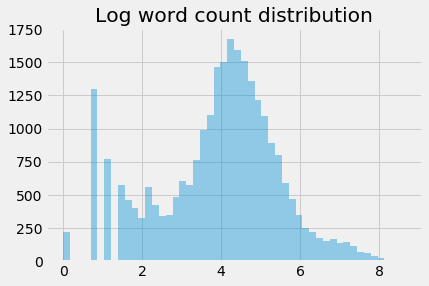

```python
word_count = pd.Series(documents).str.split().str.len()
ax = sns.distplot(np.log(word_count), kde=False)
ax.set_title('Log word count distribution');
```

```python
word_count.describe(percentiles=np.arange(.1, 1.0, .1))
```

```
count   26,314.00
mean       139.59
std        287.04
min          1.00
10%          4.00
20%         13.00
30.0%       30.00
40%         46.00
50%         63.00
60%         83.00
70%        113.00
80%        163.00
90%        279.00
max      5,718.00
dtype: float64
```

```python
token_count = Counter()
for i, doc in enumerate(documents, 1):
    if i % 5000 == 0:
        print(i, end=' ', flush=True)
    token_count.update(doc.split())
```

```
5000 10000 15000 20000 25000
```

### Most frequent tokens

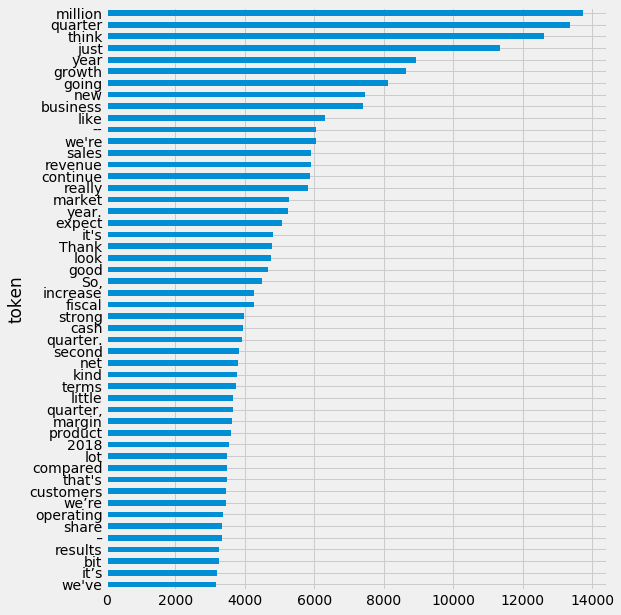

```python
(pd.DataFrame(token_count.most_common(), columns=['token', 'count'])
 .pipe(lambda x: x[~x.token.str.lower().isin(stop_words)])
 .set_index('token')
 .squeeze()
 .iloc[:50]
 .sort_values()
 .plot
 .barh(figsize=(8, 10)));
```

## Preprocess Transcripts

We use spaCy to preprocess these documents as illustrated in Chapter 13 - Working with Text Data and store the cleaned and lemmatized text as a new text file.

```python
def clean_doc(d):
    doc = []
    for t in d:
        if not any([t.is_stop, t.is_digit, not t.is_alpha, t.is_punct, t.is_space, t.lemma_ == '-PRON-']):
            doc.append(t.lemma_)
    return ' '.join(doc)
```

```python
nlp = spacy.load('en')
clean_docs = []
for i, document in enumerate(documents, 1):
    if i % 1000 == 0:
        print(f'{i/len(documents):.2%}', end=' ', flush=True)
    doc = nlp(document)
    cleaned = clean_doc(doc)
    if len(cleaned) > 0:
        clean_docs.append(cleaned)
```

```
3.80% 7.60% 11.40% 15.20% 19.00% 22.80% 26.60% 30.40% 34.20% 38.00% 41.80% 45.60% 49.40% 53.20% 57.00% 60.80% 64.60% 68.40% 72.20% 76.01% 79.81% 83.61% 87.41% 91.21% 95.01% 98.81%
```

```python
clean_text.write_text('\n'.join(clean_docs))
```

```
12133756
```

## Vectorize data

```python
docs = []
for line in clean_text.read_text().split('\n'):
    line = [t for t in line.split() if t not in stop_words]
    if len(line) > 10:
        docs.append(' '.join(line))

len(docs)
```

```
18600
```

```python
token_count = Counter()
for i, doc in enumerate(docs, 1):
    if i % 5000 == 0:
        print(i, end=' ', flush=True)
    token_count.update(doc.split())
token_count = pd.DataFrame(token_count.most_common(), columns=['token', 'count'])
```

```
5000 10000 15000
```

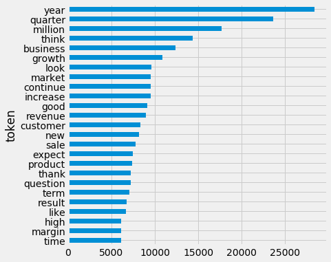

```python
(token_count
 .set_index('token')
 .squeeze()
 .iloc[:25]
 .sort_values()
 .plot
 .barh(figsize=(6, 6)));
```

```python
frequent_words = token_count.head(50).token.tolist()
binary_vectorizer = CountVectorizer(max_df=1.0,
                             min_df=1,
                             stop_words=frequent_words,
                             max_features=None,
                             binary=True)

binary_dtm = binary_vectorizer.fit_transform(docs)

n_docs, n_tokens = binary_dtm.shape
doc_freq = pd.Series(np.array(binary_dtm.sum(axis=0)).squeeze()).div(binary_dtm.shape[0])
max_unique_tokens = np.array(binary_dtm.sum(axis=1)).squeeze().max()
```

```python
df_range = FloatRangeSlider(value=[0.0, 1.0],
                            min=0,
                            max=1,
                            step=0.0001,
                            description='Doc. Freq.',
                            disabled=False,
                            continuous_update=True,
                            orientation='horizontal',
                            readout=True,
                            readout_format='.1%',
                            layout={'width': '800px'})

@interact(df_range=df_range)
def document_frequency_simulator(df_range):
    min_df, max_df = df_range
    keep = doc_freq.between(left=min_df, right=max_df)
    left = keep.sum()

    fig, axes = plt.subplots(ncols=2, figsize=(14, 6))
    updated_dtm = binary_dtm.tocsc()[:, np.flatnonzero(keep)]
    unique_tokens_per_doc = np.array(updated_dtm.sum(axis=1)).squeeze()
    sns.distplot(unique_tokens_per_doc, ax=axes[0], kde=False, norm_hist=False)
    axes[0].set_title('Unique Tokens per Doc')
    axes[0].set_yscale('log')
    axes[0].set_xlabel('# Unique Tokens')
    axes[0].set_ylabel('# Documents (log scale)')
    axes[0].set_xlim(0, max_unique_tokens)
    axes[0].yaxis.set_major_formatter(ScalarFormatter())

    term_freq = pd.Series(np.array(updated_dtm.sum(axis=0)).squeeze())
    sns.distplot(term_freq, ax=axes[1], kde=False, norm_hist=False)
    axes[1].set_title('Document Frequency')
    axes[1].set_ylabel('# Tokens')
    axes[1].set_xlabel('# Documents')
    axes[1].set_yscale('log')
    axes[1].set_xlim(0, n_docs)
#     axes[1].yaxis.set_major_formatter(ScalarFormatter())

    title = f'Document/Term Frequency Distribution | # Tokens: {left:,d} ({left/n_tokens:.2%})'
    fig.suptitle(title, fontsize=14)
    fig.tight_layout()
    fig.subplots_adjust(top=.9)
```

## Train & Evaluate LDA Model

```python
def show_word_list(model, corpus, top=10, save=False):
    top_topics = model.top_topics(corpus=corpus, coherence='u_mass', topn=20)
    words, probs = [], []
    for top_topic, _ in top_topics:
        words.append([t[1] for t in top_topic[:top]])
        probs.append([t[0] for t in top_topic[:top]])

    fig, ax = plt.subplots(figsize=(model.num_topics*1.2, 5))
    sns.heatmap(pd.DataFrame(probs).T,
                annot=pd.DataFrame(words).T,
                fmt='',
                ax=ax,
                cmap='Blues',
                cbar=False)
    fig.tight_layout()
    if save:
        fig.savefig('earnings_call_wordlist', dpi=300)
```

```python
def show_coherence(model, corpus, tokens, top=10, cutoff=0.01):
    top_topics = model.top_topics(corpus=corpus, coherence='u_mass', topn=20)
    word_lists = pd.DataFrame(model.get_topics().T, index=tokens)
    order = []
    for w, word_list in word_lists.items():
        target = set(word_list.nlargest(top).index)
        for t, (top_topic, _) in enumerate(top_topics):
            if target == set([t[1] for t in top_topic[:top]]):
                order.append(t)

    fig, axes = plt.subplots(ncols=2, figsize=(15,5))
    title = f'# Words with Probability > {cutoff:.2%}'
    (word_lists.loc[:, order]>cutoff).sum().reset_index(drop=True).plot.bar(title=title, ax=axes[1]);

    umass = model.top_topics(corpus=corpus, coherence='u_mass', topn=20)
    pd.Series([c[1] for c in umass]).plot.bar(title='Topic Coherence', ax=axes[0])
    fig.tight_layout();
```

```python
def show_top_docs(model, corpus, docs):
    doc_topics = model.get_document_topics(corpus)
    df = pd.concat([pd.DataFrame(doc_topic,
                                 columns=['topicid', 'weight']).assign(doc=i)
                    for i, doc_topic in enumerate(doc_topics)])

    for topicid, data in df.groupby('topicid'):
        print(topicid, docs[int(data.sort_values('weight', ascending=False).iloc[0].doc)])
        print(pd.DataFrame(lda.show_topic(topicid=topicid)))
```

### Vocab Settings

```python
min_df = .005
max_df=.5
ngram_range=(1, 1)
binary = False
```

```python
vectorizer = CountVectorizer(stop_words=frequent_words,
                             min_df=min_df,
                             max_df=max_df,
                             ngram_range=ngram_range,
                             binary=binary)
```

```python
dtm = vectorizer.fit_transform(docs)
tokens = vectorizer.get_feature_names()
dtm.shape
```

```
(18600, 1541)
```

```python
corpus = Sparse2Corpus(dtm, documents_columns=False)
id2word = pd.Series(tokens).to_dict()
dictionary = Dictionary.from_corpus(corpus, id2word)
```

### Model Settings

```python
num_topics=15
chunksize=2000
passes=25
update_every=None
alpha='auto'
eta='auto'
decay=0.5
offset=1.0
eval_every=None
iterations=50
gamma_threshold=0.001
minimum_probability=0.01
minimum_phi_value=0.01
per_word_topics=False
```

```python
lda = LdaModel(corpus=corpus,
               id2word=id2word,
               num_topics=num_topics,
               chunksize=chunksize,
               update_every=update_every,
               alpha=alpha,
               eta=eta,
               decay=decay,
               offset=offset,
               eval_every=eval_every,
               passes=passes,
               iterations=iterations,
               gamma_threshold=gamma_threshold,
               minimum_probability=minimum_probability,
               minimum_phi_value=minimum_phi_value,
               random_state=42)
```

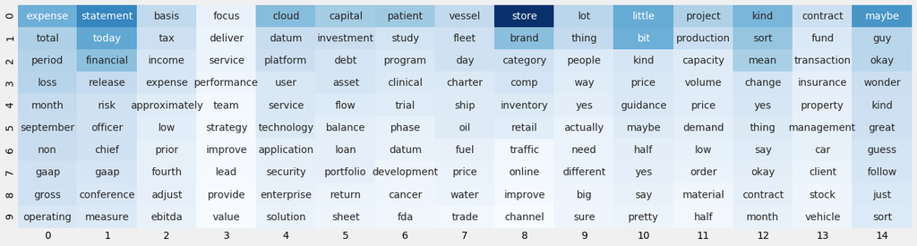

```python
show_word_list(model=lda, corpus=corpus, save=True)
```

### Topic Coherence

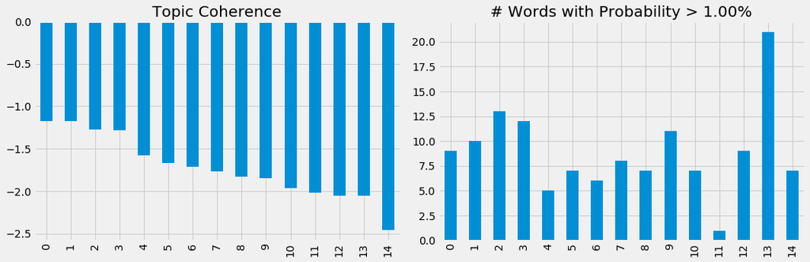

```python
show_coherence(model=lda, corpus=corpus, tokens=tokens)
```

### pyLDAVis

```python
vis = prepare(lda, corpus, dictionary, mds='tsne')
pyLDAvis.display(vis)
```

[interactive chart not shown]

### Show documents most represenative of each topic

```python
show_top_docs(model=lda, corpus=corpus, docs=docs)
```

```
0 excellent thank guy question nice quarter want dig security business assume real outperformance real highlight recent quarter question think sustainability growth nice acceleration overall growth decline trend line think sort accelerate trend line today breadth product sustain accelerate trend lin…
        0    1
0   maybe 0.04
1     guy 0.02
2    okay 0.02
3  wonder 0.02
4    kind 0.02
5   great 0.02
6   guess 0.02
7  follow 0.02
8    just 0.01
9    sort 0.01
1 thank rick like mention important point conclude today conference want insight additional important initiative expect positively impact performance continue invest key personnel add new marketing sale resource key location globe example key personnel increase sale activity recent sale win european…
             0    1
0        focus 0.01
```

[output cut: 165 more lines]

## Review Experiment Results

To illustrate the impact of different parameter settings, we run a few hundred experiments for different DTM constraints and model parameters. More specifically, we let the min_df and max_df parameters range from 50-500 words and 10% to 100% of documents, respectively using alternatively binary and absolute counts. We then train LDA models with 3 to 50 topics, using 1 and 25 passes over the corpus.

The script run_experiments.py lets you train many topic models with different hyperparameters to explore how they impact the results. The script collect_experiments.py combines the results into a `results.h5` HDF store.

These results are not included in the repository due to their size, but the results are displayed and you can rerun these experiments with earnings call transcripts or other text documents of your choice.

```python
with pd.HDFStore('results.h5') as store:
    perplexity = store.get('perplexity')
    coherence = store.get('coherence')
```

```python
perplexity.info()
```

```
<class 'pandas.core.frame.DataFrame'>
Int64Index: 496 entries, 0 to 15
Data columns (total 8 columns):
vocab_size    496 non-null int64
test_vocab    496 non-null int64
min_df        496 non-null int64
max_df        496 non-null float64
binary        496 non-null bool
num_topics    496 non-null int64
passes        496 non-null int64
perplexity    496 non-null float64
dtypes: bool(1), float64(2), int64(5)
memory usage: 31.5 KB
```

```python
coherence.info()
```

```
<class 'pandas.core.frame.DataFrame'>
Int64Index: 8370 entries, 0 to 713
Data columns (total 7 columns):
topic         8370 non-null int64
passes        8370 non-null object
num_topics    8370 non-null object
coherence     8370 non-null float64
min_df        8370 non-null int64
max_df        8370 non-null float64
binary        8370 non-null bool
dtypes: bool(1), float64(2), int64(2), object(2)
memory usage: 465.9+ KB
```

### Parameter Settings: Impact on Perplexity

```python
X = perplexity[['min_df', 'max_df', 'binary', 'num_topics','passes']]
X = pd.get_dummies(X, columns=X.columns, drop_first=True)
ols = sm.OLS(endog=perplexity.perplexity, exog=sm.add_constant(X))
model = ols.fit(cov_type='HC0')
print(model.summary())
```

```
                            OLS Regression Results
==============================================================================
Dep. Variable:             perplexity   R-squared:                       0.772
Model:                            OLS   Adj. R-squared:                  0.765
Method:                 Least Squares   F-statistic:                     75.71
Date:                Mon, 03 Dec 2018   Prob (F-statistic):          5.53e-116
Time:                        15:34:14   Log-Likelihood:                -2407.9
No. Observations:                 496   AIC:                             4848.
Df Residuals:                     480   BIC:                             4915.
Df Model:                          15
Covariance Type:                  HC0
=================================================================================
                    coef    std err          z      P>|z|      [0.025      0.975]
---------------------------------------------------------------------------------
const           158.0331      5.804     27.227      0.000     146.657     169.409
min_df_100      -34.7269      4.675     -7.428      0.000     -43.890     -25.564
min_df_250      -77.8456      4.348    -17.903      0.000     -86.368     -69.323
min_df_500     -108.7279      4.475    -24.295      0.000    -117.500     -99.956
max_df_0.25     -20.5220      4.448     -4.614      0.000     -29.240     -11.804
max_df_0.5      -30.2190      4.287     -7.050      0.000     -38.620     -21.818
max_df_1.0      -29.6129      4.442     -6.666      0.000     -38.319     -20.906
binary_True      40.5022      2.764     14.651      0.000      35.084      45.920
num_topics_5      2.4029      3.747      0.641      0.521      -4.941       9.747
num_topics_7      5.7087      3.566      1.601      0.109      -1.280      12.697
num_topics_10    11.3472      3.353      3.385      0.001       4.776      17.918
num_topics_15    20.6403      3.259      6.332      0.000      14.252      27.029
num_topics_20    30.0500      3.500      8.585      0.000      23.190      36.910
num_topics_25    39.5115      4.040      9.780      0.000      31.593      47.430
num_topics_50    89.8369      9.679      9.282      0.000      70.866     108.808
passes_25       -25.4013      2.789     -9.108      0.000     -30.867     -19.935
==============================================================================
Omnibus:                      459.795   Durbin-Watson:                   1.195
Prob(Omnibus):                  0.000   Jarque-Bera (JB):            19757.525
Skew:                           3.888   Prob(JB):                         0.00
Kurtosis:                      32.926   Cond. No.                         12.1
==============================================================================

Warnings:
[1] Standard Errors are heteroscedasticity robust (HC0)
```

### Parameter Settings: Impact on Coherence

```python
X = coherence.drop('coherence', axis=1)
X = pd.get_dummies(X, columns=X.columns, drop_first=True)
ols = sm.OLS(endog=coherence.coherence, exog=sm.add_constant(X))
model = ols.fit(cov_type='HC0')
print(model.summary())
```

```
                            OLS Regression Results
==============================================================================
Dep. Variable:              coherence   R-squared:                       0.665
Model:                            OLS   Adj. R-squared:                  0.663
Method:                 Least Squares   F-statistic:                     237.0
Date:                Mon, 03 Dec 2018   Prob (F-statistic):               0.00
Time:                        15:50:17   Log-Likelihood:                -4925.0
No. Observations:                8370   AIC:                             9980.
Df Residuals:                    8305   BIC:                         1.044e+04
Df Model:                          64
Covariance Type:                  HC0
=================================================================================
                    coef    std err          z      P>|z|      [0.025      0.975]
---------------------------------------------------------------------------------
const            -1.5492      0.023    -66.490      0.000      -1.595      -1.504
topic_1          -0.1076      0.020     -5.501      0.000      -0.146      -0.069
topic_2          -0.2316      0.020    -11.553      0.000      -0.271      -0.192
topic_3          -0.3080      0.019    -16.228      0.000      -0.345      -0.271
topic_4          -0.4257      0.019    -21.936      0.000      -0.464      -0.388
topic_5          -0.4553      0.019    -23.826      0.000      -0.493      -0.418
topic_6          -0.5660      0.021    -27.289      0.000      -0.607      -0.525
topic_7          -0.5650      0.020    -28.721      0.000      -0.604      -0.526
topic_8          -0.6366      0.020    -31.807      0.000      -0.676      -0.597
topic_9          -0.7315      0.022    -32.944      0.000      -0.775      -0.688
topic_10         -0.7038      0.020    -34.972      0.000      -0.743      -0.664
topic_11         -0.7618      0.020    -37.648      0.000      -0.801      -0.722
topic_12         -0.8278      0.021    -39.529      0.000      -0.869      -0.787
topic_13         -0.9086      0.024    -37.905      0.000      -0.956      -0.862
topic_14         -1.0062      0.028    -36.165      0.000      -1.061      -0.952
topic_15         -0.9400      0.020    -46.426      0.000      -0.980      -0.900
topic_16         -1.0064      0.021    -48.362      0.000      -1.047      -0.966
topic_17         -1.0891      0.024    -45.451      0.000      -1.136      -1.042
topic_18         -1.2143      0.035    -34.359      0.000      -1.284      -1.145
topic_19         -1.3974      0.051    -27.558      0.000      -1.497      -1.298
topic_20         -1.2093      0.032    -38.068      0.000      -1.272      -1.147
topic_21         -1.3008      0.043    -30.040      0.000      -1.386      -1.216
topic_22         -1.3990      0.048    -28.894      0.000      -1.494      -1.304
topic_23         -1.5555      0.075    -20.642      0.000      -1.703      -1.408
topic_24         -1.8207      0.102    -17.928      0.000      -2.020      -1.622
topic_25         -1.2510      0.027    -47.049      0.000      -1.303      -1.199
```

[output cut: 33 more lines]

```
min_df_250        0.4365      0.016     27.103      0.000       0.405       0.468
min_df_500        0.5494      0.016     33.442      0.000       0.517       0.582
max_df_0.25       0.2821      0.014     20.594      0.000       0.255       0.309
max_df_0.5        0.2855      0.013     21.696      0.000       0.260       0.311
max_df_1.0        0.2830      0.014     20.323      0.000       0.256       0.310
binary_True      -0.1248      0.010    -12.994      0.000      -0.144      -0.106
==============================================================================
Omnibus:                     5210.657   Durbin-Watson:                   0.513
Prob(Omnibus):                  0.000   Jarque-Bera (JB):           124064.587
Skew:                          -2.572   Prob(JB):                         0.00
Kurtosis:                      21.146   Cond. No.                         49.5
==============================================================================

Warnings:
[1] Standard Errors are heteroscedasticity robust (HC0)
```

### Hyperparameter Impact on Perplexity

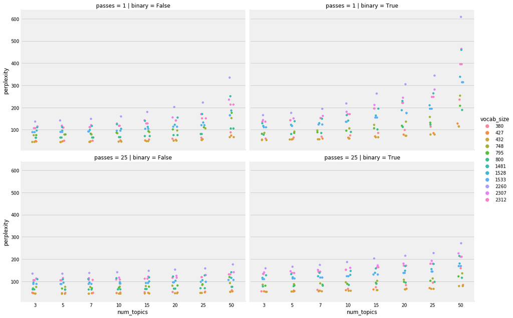

```python
sns.catplot(x='num_topics',
            y='perplexity',
            data=perplexity,
            hue='vocab_size',
            col='binary',
            row='passes',
            kind='strip',
           aspect=1.5);
```

```python
coherence.num_topics = coherence.num_topics.apply(lambda x: f'model_{int(x):0>2}')
perplexity.min_df = perplexity.min_df.apply(lambda x: f'min_df_{int(x):0>3}')
```

### Hyperparameter Impact on Topic Coherence

The following chart illustrate the results in terms of topic coherence (higher is better) ,and perplexity (lower is better). Coherence drops after 25-30 topics, and perplexity similarly increases.

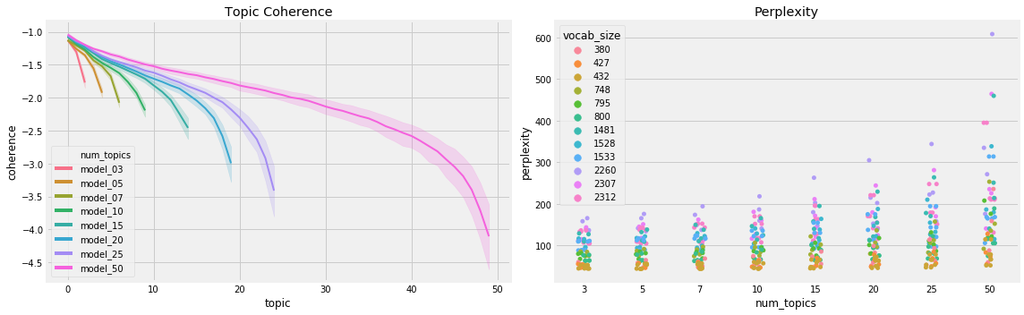

```python
fig, axes = plt.subplots(ncols=2, figsize=(16,5))
data = coherence.sort_values('num_topics')
sns.lineplot(x='topic', y='coherence', hue='num_topics', data=data, lw=2, ax=axes[0])
axes[0].set_title('Topic Coherence')
sns.stripplot(x='num_topics', y='perplexity', hue='vocab_size', data=perplexity, lw=2, ax=axes[1])
axes[1].set_title('Perplexity')
fig.tight_layout()
fig.savefig('earnings_call_model_eval', dpi=300);
```

## Load Experiment

The following code let's you load and explore the topic model for a specific experiment run.

### Load Document-Term Matrix

```python
max_df = .1    # [.1, .25, .5, 1.0]
min_df = 250   # [50, 100, 250, 500]
binary= False  # [True, False]
```

```python
vocab_path = experiment_path / str(min_df) / str(max_df) / str(int(binary))
exp_dtm = sparse.load_npz(vocab_path / f'dtm.npz')
exp_tokens = pd.read_csv(vocab_path / f'tokens.csv', header=None, squeeze=True)
exp_dtm.shape
```

```
(22766, 748)
```

```python
exp_id2word = exp_tokens.to_dict()
exp_corpus = Sparse2Corpus(exp_dtm, documents_columns=False)
exp_dictionary = Dictionary.from_corpus(exp_corpus, exp_id2word)
```

```python
exp_train_dtm, exp_test_dtm = train_test_split(exp_dtm, test_size=.1)
```

```python
exp_test_dtm
```

```
<2277x748 sparse matrix of type '<class 'numpy.int64'>'
	with 49568 stored elements in Compressed Sparse Row format>
```

```python
exp_test_corpus = Sparse2Corpus(exp_test_dtm, documents_columns=False)
```

### Set Model Parameters

```python
num_topics = 20 # [3, 5, 7, 10, 15, 20, 25, 50]
passes = 25    # [1, 25]
```

```python
exp_model_path = vocab_path / str(num_topics) / str(passes)
exp_lda = LdaModel.load(str(exp_model_path / 'lda'))
```

```python
2 ** (-exp_lda.log_perplexity(exp_test_corpus))
```

```
84.52873752805492
```

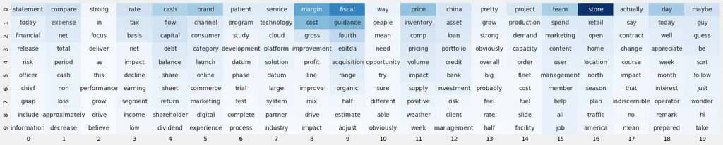

```python
show_word_list(model=exp_lda, corpus=exp_corpus)
```

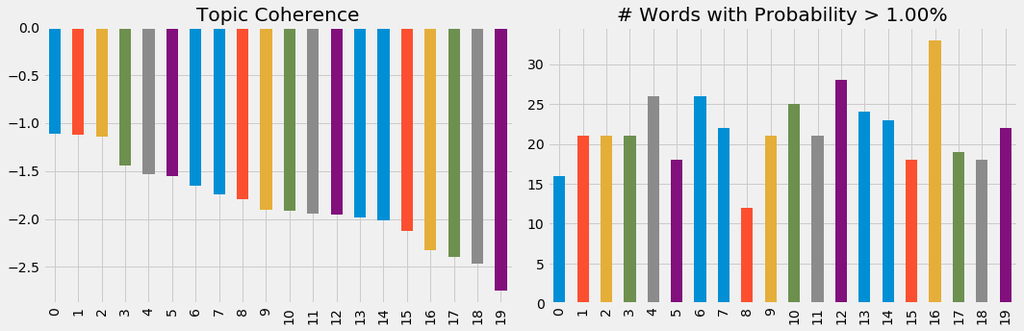

```python
show_coherence(model=exp_lda, corpus=exp_corpus, tokens=exp_tokens)
```

```python
exp_vis = prepare(exp_lda, exp_corpus, exp_dictionary, mds='tsne')
pyLDAvis.display(exp_vis)
```

[interactive chart not shown]

### Review Documents by Topic

```python
exp_docs = []
for line in clean_text.read_text().split('\n'):
        exp_docs.append(line)
len(exp_docs)
```

```
22745
```

```python
doc_topics = exp_lda.get_document_topics(exp_corpus)
df = pd.concat([pd.DataFrame(doc_topic, columns=['topicid', 'weight']).assign(doc=i) for i, doc_topic in enumerate(doc_topics)])
```

```python
for topicid, data in df.groupby('topicid'):
    print(topicid, exp_docs[int(data.sort_values('weight', ascending=False).iloc[0].doc)])
    print(pd.DataFrame(exp_lda.show_topic(topicid=topicid)))
```

```
0 no real update give time continue different clinical program hifu application so track update give far
            0    1
0     project 0.05
1  production 0.03
2      demand 0.03
3    capacity 0.02
4       order 0.02
5       fleet 0.02
6        cost 0.02
7        fuel 0.02
8       slide 0.02
9    facility 0.02
1 okay understand and second question multipart hopefully quick the ballast water treatment mention coast guard approval think important can feeling timing so schedule far number ship year what hire time associate ship fitting ballast water treatment system cost ship and cost expense amortize
            0    1
0     service 0.04
```

[output cut: 225 more lines]